# A dive into R Markdown

MACS 30500 University of Chicago

## Reproducibility in scientific research

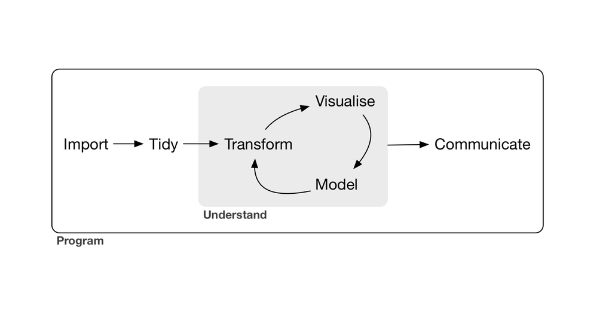

## R Markdown basics

````
---
title: "Gun deaths"
date: 2017-02-01
output: html_document
---

```{r setup, include = FALSE}
library(tidyverse)
library(rcfss)

youth <- gun_deaths %>%
  filter(age <= 65)
```

We have data about `r nrow(gun_deaths)` individuals killed by guns. Only `r nrow(gun_deaths) - nrow(youth)` are older than 65. The distribution of the remainder is shown below:

```{r youth-dist, echo = FALSE}
youth %>%
  ggplot(aes(age)) +
  geom_freqpoly(binwidth = 1)
```
````

## Major components

1. A **YAML header** surrounded by `---`s
2. **Chunks** of R code surounded by `` ``` ``
3. Text mixed with simple text formatting using the Markdown syntax

## Knitting process

## Exercise

[figure not shown]

## Code chunks

- Naming code chunks
- Code chunk options
- `eval = FALSE`
- `include = FALSE`
- `echo = FALSE`
- `message = FALSE` or `warning = FALSE`
- `results = 'hide'`
- `error = TRUE`

## Caching

- Saving results of computationally intensive chunks
- Reuse each time chunk is knitted

## Dependencies

````
```{r raw_data}
rawdata <- readr::read_csv("a_very_large_file.csv")
```

```{r processed_data, cache = TRUE}
processed_data <- rawdata %>%
  filter(!is.na(import_var)) %>%
  mutate(new_variable = complicated_transformation(x, y, z))
```
````

## Dependencies

````
```{r raw_data}
rawdata <- readr::read_csv("a_very_large_file.csv")
```

```{r processed_data, cache = TRUE, dependson = "raw_data"}
processed_data <- rawdata %>%
  filter(!is.na(import_var)) %>%
  mutate(new_variable = complicated_transformation(x, y, z))
```
````

## Global options

```r
knitr::opts_chunk$set(
  echo = FALSE
)
```

## Inline code

> We have data about `` `r nrow(gun_deaths)` `` individuals killed by guns. Only `` `r nrow(gun_deaths) - nrow(youth)` `` are older than 65. The distribution of the remainder is shown below:

> We have data about 100798 individuals killed by guns. Only 15687 are older than 65. The distribution of the remainder is shown below:

## Exercise: practice chunk options

[figure not shown]

## YAML header

```
---
title: "Gun deaths"
author: "Benjamin Soltoff"
date: 2017-02-01
output: html_document
---
```

- **Y**et **A**nother **M**arkup **L**anguage
- Standardized format for storing hierarchical data in a human-readable syntax
- Defines how `rmarkdown` renders your `.Rmd` file

## HTML document

```
---
title: "Untitled"
author: "Benjamin Soltoff"
date: "February 1, 2017"
output: html_document
---
```

## Table of contents

```
---
title: "Untitled"
author: "Benjamin Soltoff"
date: "February 1, 2017"
output:
  html_document:
    toc: true
    toc_depth: 2
```

## Appearance and style

```
---
title: "Untitled"
author: "Benjamin Soltoff"
date: "February 1, 2017"
output:
  html_document:
    theme: readable
    highlight: pygments
---
```

- `theme` specifies the Bootstrap theme to use for the page
- `highlight` specifies the syntax highlighting style for code chunks

## Code folding

```
---
title: "Untitled"
author: "Benjamin Soltoff"
date: "February 1, 2017"
output:
  html_document:
    code_folding: hide
---
```

## Keeping Markdown

```
---
title: "Untitled"
author: "Benjamin Soltoff"
date: "February 1, 2017"
output:
  html_document:
    keep_md: true
---
```

## Exercise: test HTML options

[figure not shown]

## PDF document

```
---
title: "Gun deaths"
date: 2017-02-01
output: pdf_document
---
```

- Renders as PDF using $\LaTeX$

## Table of contents

```
---
title: "Untitled"
author: "Benjamin Soltoff"
date: "February 1, 2017"
output:
  pdf_document:
    toc: true
    toc_depth: 2
```

## Syntax highlighting

```
---
title: "Untitled"
author: "Benjamin Soltoff"
date: "February 1, 2017"
output:
  pdf_document:
    highlight: pygments
---
```

## $\LaTeX$ options

```
---
title: "Untitled"
author: "Benjamin Soltoff"
date: "February 1, 2017"
output: pdf_document
fontsize: 11pt
geometry: margin=1in
---
```

## Keep intermediate TeX

```
---
title: "Untitled"
author: "Benjamin Soltoff"
date: "February 1, 2017"
output:
  pdf_document:
    keep_tex: true
---
```

## Exercise: test PDF options

[figure not shown]

## Presentations

- [ioslides](http://rmarkdown.rstudio.com/ioslides_presentation_format.html)
- [reveal.js](http://rmarkdown.rstudio.com/revealjs_presentation_format.html)
- [Slidy](http://rmarkdown.rstudio.com/slidy_presentation_format.html)
- [Beamer](http://rmarkdown.rstudio.com/beamer_presentation_format.html)

## Exercise: build a presentation

[figure not shown]

## Multiple formats

```
output:
  html_document:
    toc: true
    toc_float: true
  pdf_document: default
```

## Rendering multiple outputs programmatically

```r
rmarkdown::render("my-document.Rmd",
                  output_format = "all")
```

## Exercise: render in multiple formats

[figure not shown]

## R scripts

[output not shown]

## When to use a script

- For troubleshooting
- Initial stages of project
- Building a reproducible pipeline
- It depends
- Running scripts interactively
- Running scripts programmatically
  - `source()`

## Running scripts via the shell

```bash
Rscript gun-deaths.R
```

```bash
Rscript -e "rmarkdown::render('gun-deaths.Rmd')"
```

## Exercise: execute R scripts

[figure not shown]